# Video Games and Attitude Change: A Meta-analysis

2021-10-29

**This is the supplementary analytic output for the paper Video Games and Attitude Change: A Meta-analysis**

**It reports detailed results for all models reported in the paper. The analytic R script by which this html report was generated can be found on the project’s OSF page at: https://osf.io/4aeqt/**

**Brief information about the methods used in the analysis:**

**RMA results with model-based SEs** k = number of studies; sqrt in “Variance components” = tau, the standard deviation of true effects; estimate in “Model results” = naive MA estimate

**RVE SEs with Satterthwaite small-sample correction** Estimate based on a multilevel RE model with constant sampling correlation model (CHE - correlated hierarchical effects - working model) (Pustejovsky & Tipton, 2020; https://osf.io/preprints/metaarxiv/vyfcj/). Interpretation of naive-meta-analysis should be based on these estimates.

**Prediction interval** Shows the expected range of true effects in similar studies. As an approximation, in 95% of cases the true effect in a new *published* study can be expected to fall between PI LB and PI UB. Note that these are non-adjusted estimates. An unbiased newly conducted study will more likely fall in an interval centered around bias-adjusted estimate with a wider CI width.

**Heterogeneity** Tau can be interpreted as the total amount of heterogeneity in the true effects. I^2$ represents the ratio of true heterogeneity to total variance across the observed effect estimates. Estimates calculated by two approaches are reported. This is followed by separate estimates of between- and within-cluster heterogeneity and estimated intra-class correlation of underlying true effects.

**Proportion of significant results** What proportion of effects were statistically at the alpha level of .05.

**ES-precision correlation** Kendalls’s correlation between the ES and precision.

**4/3PSM** Applies a permutation-based, step-function 4-parameter selection model (one-tailed p-value steps = c(.025, .5, 1)). Falls back to 3-parameter selection model if at least one of the three p-value intervals contains less than 5 p-values. For this meta-analysis, we applied 3-parameter selection model by default as there were only 11 independent effects in the opposite direction overall (6%), causing the estimates to be unstable across iterations. pvalue = p-value testing H0 that the effect is zero. ciLB and ciUB are lower and upper bound of the CI. k = number of studies. steps = 3 means that the 4PSM was applied, 2 means that the 3PSM was applied. We also ran two sensitivity analyses of the selection model, the Vevea & Woods (2005) step function model with a priori defined selection weights and the Robust Bayesian Meta-analysis model employing the model-averaging approach (Bartoš & Maier, 2020).

**PET-PEESE** Estimated effect size of an infinitely precise study. Using 4/3PSM as the conditional estimator instead of PET (can be changed to PET). If the PET-PEESE estimate is in the opposite direction, the effect can be regarded nil. By default (can be changed to PET), the function employs a modified sample-size based estimator (see https://www.jepusto.com/pet-peese-performance/). It also uses the same RVE sandwich-type based estimator in a CHE (correlated hierarchical effects) working model with the identical random effects structure as the primary (naive) meta-analytic model.

We report results for both, PET and PEESE, with the first reported one being the primary (based on the conditional estimator).

**WAAP-WLS** The combined WAAP-WLS estimator (weighted average of the adequately powered - weighted least squares) tries to identify studies that are adequately powered to detect the meta-analytic effect. If there is less than two such studies, the method falls back to the WLS estimator (Stanley & Doucouliagos, 2015). If there are at least two adequately powered studies, WAAP returns a WLS estimate based on effects from only those studies.

type = 1: WAAP estimate, 2: WLS estimate. kAdequate = number of adequately powered studies

**p-uniform** P-uniform* is a selection model conceptually similar to p-curve. It makes use of the fact that p-values follow a uniform distribution at the true effect size while it includes also nonsignificant effect sizes. Permutation-based version of p-uniform method, the so-called p-uniform* (van Aert, van Assen, 2021).

**p-curve** Permutation-based p-curve method. Output should be self-explanatory. For more info see p-curve.com

**Power for detecting SESOI and bias-corrected parameter estimates** Estimates of the statistical power for detecting a smallest effect sizes of interest equal to .20, .50, and .70 in SD units (Cohen’s d). A sort of a thought experiment, we also assumed that population true values equal the bias-corrected estimates (4/3PSM or PET-PEESE) and computed power for those.

**Handling of dependencies in bias-correction methods** To handle dependencies among the effects, the 4PSM, p-curve, p-uniform are implemented using a permutation-based procedure, randomly selecting only one focal effect (i.e., excluding those which were not coded as being focal) from a single study and iterating nIterations times. Lastly, the procedure selects the result with the median value of the ES estimate (4PSM, p-uniform) or median z-score of the full p-curve (p-curve).

# Descriptives

## Publication year

```
## from   to
## 2006 2020
```

## Sample sizes

### N of effects

```
## [1] 119
```

### N of studies

```
## [1] 67
```

```
## [1] 58
```

### N of papers

```
## [1] 40
```

```
## [1] 35
```

### Median N across all the ES eligible for meta-analysis

```
## [1] 127
```

### Total meta-analytic N

```
## [1] 14272
```

### Mean gender ratio (percent female)

```
## [1] 0.5556832
```

```
## [1] 0.1337519
```

### Weighted mean age of included samples

```
## [1] 21.13281
```

# Meta-analysis results

## H1: Videogames induce a change in players’ explicit (H1a) and implicit attitudes (H1b).

Number of iterations run equal to 200 for p-curve and 5000 for all other bias correction functions. For sensitivity analyses, we ran 200 iterations for the Vevea & Woods (2005) step function model. For supplementary robust bayesian model-averaging approach, we employed 2 MCMC chains with 2000 sampling iterations (2/5 burnin).

```
## $`RMA results with model-based SEs`
##
## Multivariate Meta-Analysis Model (k = 119; method: REML)
##
## Variance Components:
##
##             estim    sqrt  nlvls  fixed        factor
## sigma^2.1  0.1456  0.3816     58     no         study
## sigma^2.2  0.0110  0.1050    119     no  study/result
##
## Test for Heterogeneity:
## Q(df = 118) = 483.4957, p-val < .0001
##
## Model Results:
##
## estimate      se    zval    pval   ci.lb   ci.ub
##   0.2520  0.0572  4.4053  <.0001  0.1399  0.3642  ***
##
## ---
## Signif. codes:  0 '***' 0.001 '**' 0.01 '*' 0.05 '.' 0.1 ' ' 1
##
##
## $`RVE SEs with Satterthwaite small-sample correction`
## $`RVE SEs with Satterthwaite small-sample correction`$test
##     Coef. Estimate     SE t-stat d.f. p-val (Satt) Sig.
## 1 intrcpt    0.252 0.0572   4.41 55.9       <0.001  ***
##
## $`RVE SEs with Satterthwaite small-sample correction`$CIs
##      Coef Estimate     SE d.f. Lower 95% CI Upper 95% CI
## 1 intrcpt    0.252 0.0572 55.9        0.138        0.367
##
##
## $`Prediction interval`
## 95% PI LB 95% PI UB
##    -0.549     1.053
##
## $Heterogeneity
##                           Tau                           I^2
##                      0.395808                     92.866387
##                 Jackson's I^2 Between-cluster heterogeneity
```

[output cut: 71 more lines]

```
## - Evidential value present: yes
## - Evidential value absent/inadequate: no
##
##
## $`Power for detecting SESOI and bias-corrected parameter estimates`
##              Median power for detecting a SESOI of d = .20
##                                                    "0.355"
##              Median power for detecting a SESOI of d = .50
##                                                    "0.978"
##              Median power for detecting a SESOI of d = .70
##                                                        "1"
## Median power for detecting PET-PEESE estimate.PET estimate
##                    "ES estimate in the opposite direction"
##             Median power for detecting 4/3PSM estimate.est
##                    "ES estimate in the opposite direction"
```

### Table

```
##                             k                    g [95% CI]
##                           119             0.25 [0.14, 0.37]
##               95% PI [LB, UB]                            SE
##                 [-0.55, 1.05]                          0.06
##                           Tau                           I^2
##                           0.4                           93%
##                 % significant             3PSM est [95% CI]
##                           14%             0.33 [0.14, 0.53]
##                   3PSM.pvalue V&W [moderate/severe/extreme]
##                         0.001               0.14/0.04/-0.07
##                RoBMA [95% CI]        PET-PEESE est [95% CI]
##                0.04 [0, 0.24]           -0.03 [-0.34, 0.27]
##              PET-PEESE.pvalue
##                         0.842
```

### Forest plot

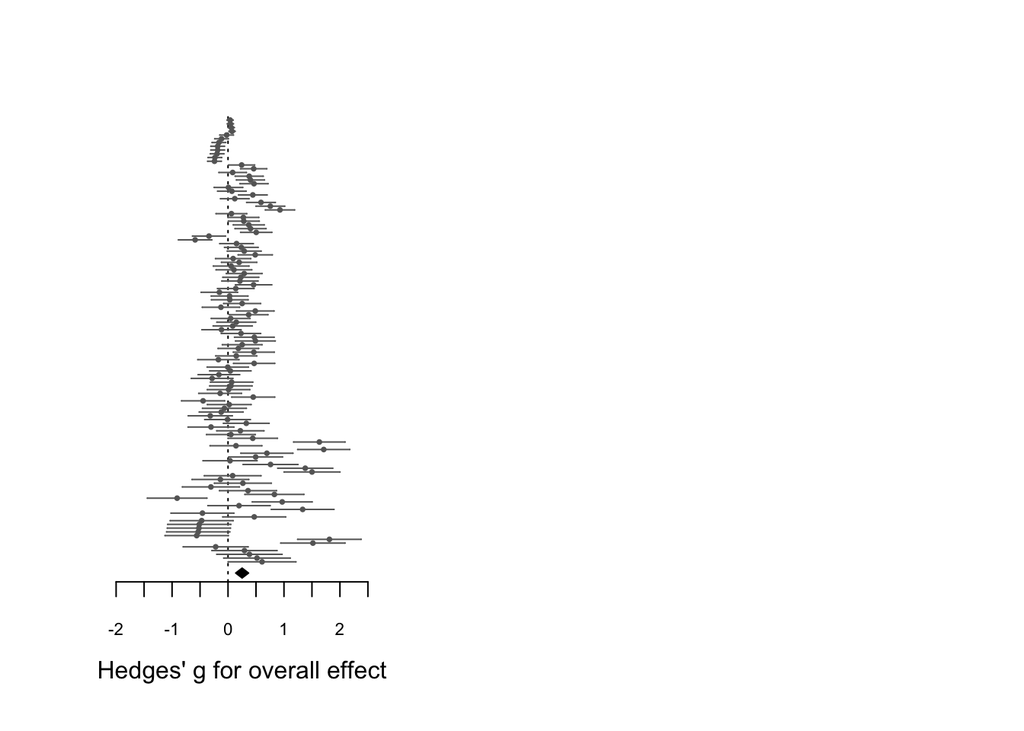

### Contour-enhanced funnel plot

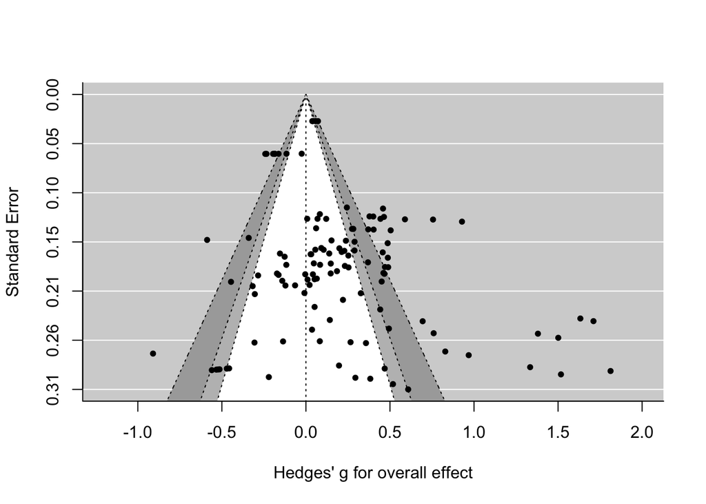

### p-curve plot

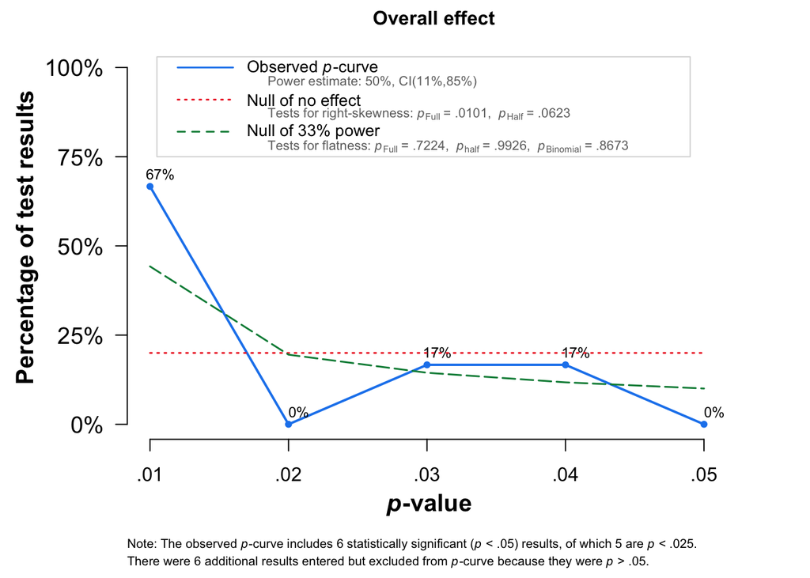

## H1a: Videogames induce a change in players’ explicit attitudes (H1a).

```
## $`RMA results with model-based SEs`
##
## Multivariate Meta-Analysis Model (k = 101; method: REML)
##
## Variance Components:
##
##             estim    sqrt  nlvls  fixed        factor
## sigma^2.1  0.1757  0.4192     50     no         study
## sigma^2.2  0.0110  0.1050    101     no  study/result
##
## Test for Heterogeneity:
## Q(df = 100) = 447.0533, p-val < .0001
##
## Model Results:
##
## estimate      se    zval    pval   ci.lb   ci.ub
##   0.2418  0.0662  3.6534  0.0003  0.1121  0.3714  ***
##
## ---
## Signif. codes:  0 '***' 0.001 '**' 0.01 '*' 0.05 '.' 0.1 ' ' 1
##
##
## $`RVE SEs with Satterthwaite small-sample correction`
## $`RVE SEs with Satterthwaite small-sample correction`$test
##     Coef. Estimate     SE t-stat d.f. p-val (Satt) Sig.
## 1 intrcpt    0.242 0.0661   3.66 48.4       <0.001  ***
##
## $`RVE SEs with Satterthwaite small-sample correction`$CIs
##      Coef Estimate     SE d.f. Lower 95% CI Upper 95% CI
## 1 intrcpt    0.242 0.0661 48.4        0.109        0.375
##
##
## $`Prediction interval`
## 95% PI LB 95% PI UB
##    -0.637     1.120
##
## $Heterogeneity
##                           Tau                           I^2
##                     0.4321381                    94.4380260
##                 Jackson's I^2 Between-cluster heterogeneity
```

[output cut: 71 more lines]

```
## - Evidential value present: yes
## - Evidential value absent/inadequate: no
##
##
## $`Power for detecting SESOI and bias-corrected parameter estimates`
##              Median power for detecting a SESOI of d = .20
##                                                    "0.355"
##              Median power for detecting a SESOI of d = .50
##                                                    "0.978"
##              Median power for detecting a SESOI of d = .70
##                                                        "1"
## Median power for detecting PET-PEESE estimate.PET estimate
##                    "ES estimate in the opposite direction"
##             Median power for detecting 4/3PSM estimate.est
##                    "ES estimate in the opposite direction"
```

## H1b: Videogames induce a change in players’ implicit attitudes (H1b).

```
## $`RMA results with model-based SEs`
##
## Multivariate Meta-Analysis Model (k = 18; method: REML)
##
## Variance Components:
##
##             estim    sqrt  nlvls  fixed        factor
## sigma^2.1  0.0000  0.0000     12     no         study
## sigma^2.2  0.0122  0.1106     18     no  study/result
##
## Test for Heterogeneity:
## Q(df = 17) = 26.1076, p-val = 0.0725
##
## Model Results:
##
## estimate      se    zval    pval   ci.lb   ci.ub
##   0.3608  0.0541  6.6694  <.0001  0.2548  0.4668  ***
##
## ---
## Signif. codes:  0 '***' 0.001 '**' 0.01 '*' 0.05 '.' 0.1 ' ' 1
##
##
## $`RVE SEs with Satterthwaite small-sample correction`
## $`RVE SEs with Satterthwaite small-sample correction`$test
##     Coef. Estimate     SE t-stat d.f. p-val (Satt) Sig.
## 1 intrcpt    0.361 0.0517   6.97 7.76       <0.001  ***
##
## $`RVE SEs with Satterthwaite small-sample correction`$CIs
##      Coef Estimate     SE d.f. Lower 95% CI Upper 95% CI
## 1 intrcpt    0.361 0.0517 7.76        0.241        0.481
##
##
## $`Prediction interval`
## 95% PI LB 95% PI UB
##     0.093     0.628
##
## $Heterogeneity
##                           Tau                           I^2
##                     0.1106172                    31.0310867
##                 Jackson's I^2 Between-cluster heterogeneity
```

[output cut: 71 more lines]

```
## - Evidential value present: yes
## - Evidential value absent/inadequate: no
##
##
## $`Power for detecting SESOI and bias-corrected parameter estimates`
##                Median power for detecting a SESOI of d = .20
##                                                        0.391
##                Median power for detecting a SESOI of d = .50
##                                                        0.988
##                Median power for detecting a SESOI of d = .70
##                                                        1.000
## Median power for detecting PET-PEESE estimate.PEESE estimate
##                                                        0.820
##               Median power for detecting 4/3PSM estimate.est
##                                                        0.298
```

### Table

```
##                               Implicit          Explicit
## k                             18                101
## g [95% CI]                    0.36 [0.24, 0.48] 0.24 [0.11, 0.37]
## 95% PI [LB, UB]               [0.09, 0.63]      [-0.64, 1.12]
## SE                            0.05              0.07
## Tau                           0.11              0.43
## I^2                           31%               94%
## % significant                 39%               10%
## 3PSM est [95% CI]             0.37 [0.2, 0.54]  0.32 [0.09, 0.55]
## 3PSM.pvalue                   0                 0.006
## V&W [moderate/severe/extreme] 0.31/0.24/0.17    0.12/0.01/-0.11
## RoBMA [95% CI]                0.34 [0, 0.45]    0.03 [0, 0.21]
## PET-PEESE est [95% CI]        0.34 [0.14, 0.55] -0.03 [-0.39, 0.33]
## PET-PEESE.pvalue              0.004             0.855
```

### Plots

Contour-enhanced funnel plots

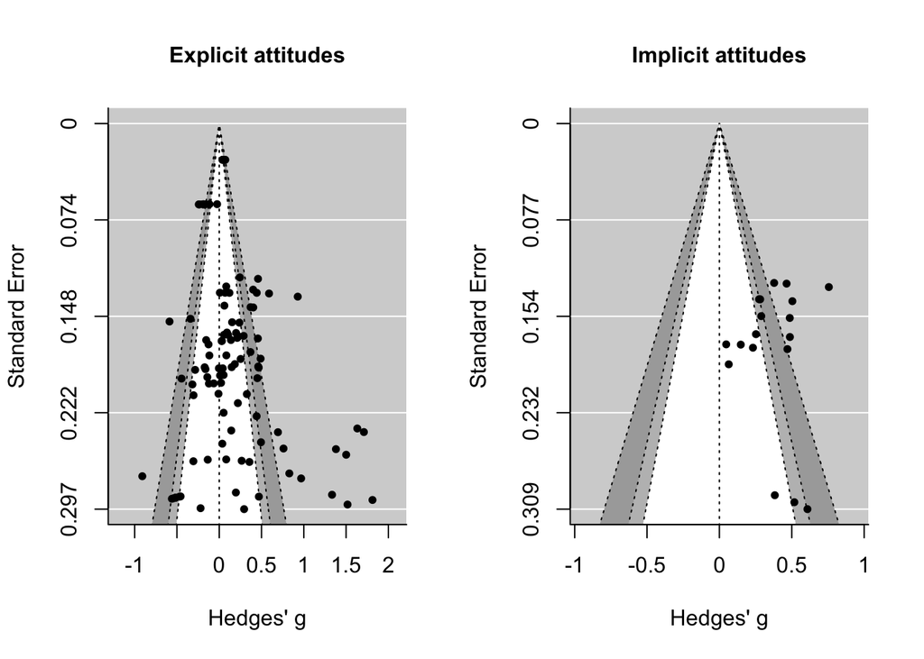

### Forest plots for the explicit and implicit attitudes effects.

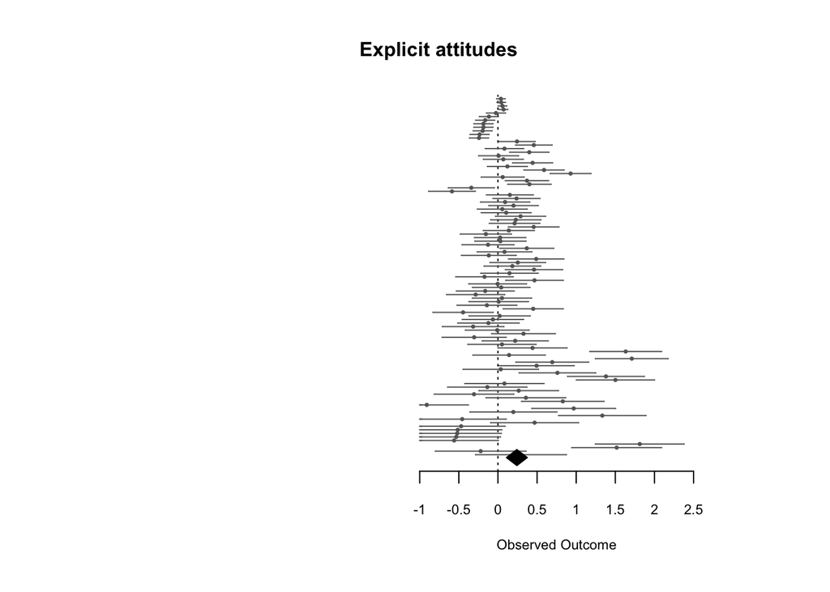

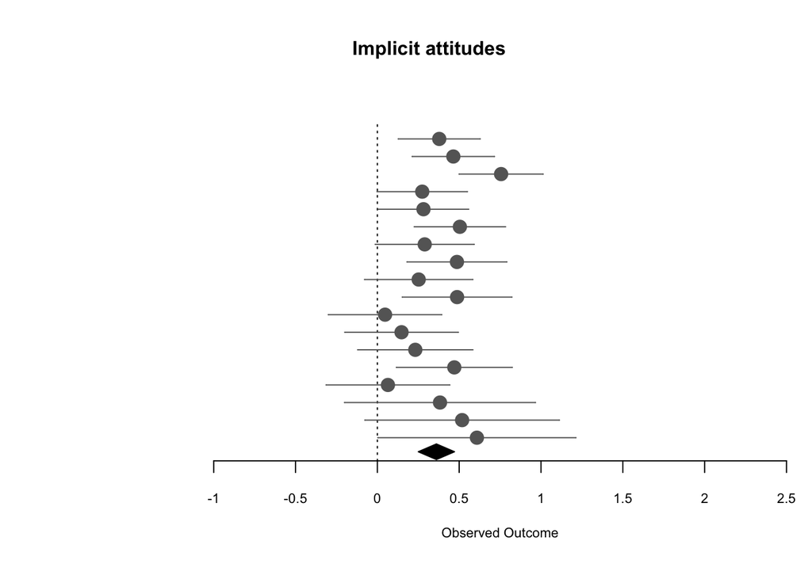

### p-curve plots

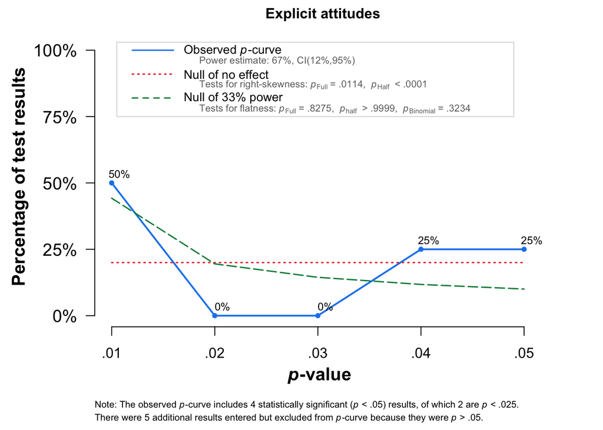

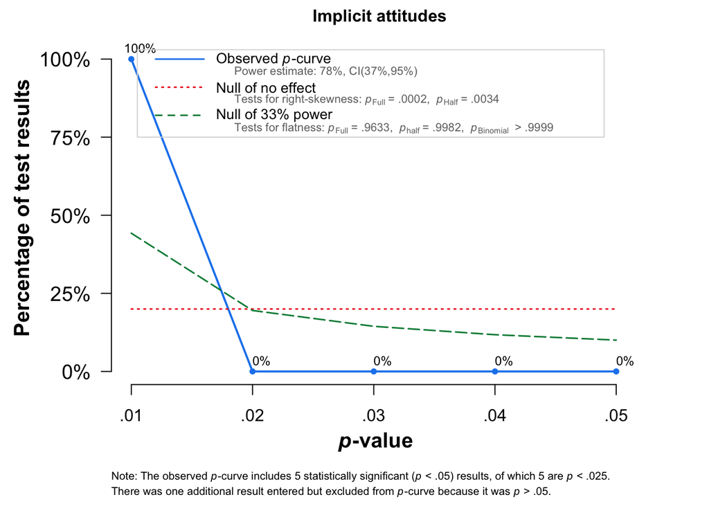

#### Comparison of effect types

Model without covariates

```
## $k
## Att_type_exp_imp
## Implicit Explicit
##       18      101
##
## $test
##                              Coef. Estimate     SE t-stat p-val (z) Sig.
## 1 factor(Att_type_exp_imp)Implicit    0.285 0.0609   4.67    <0.001  ***
## 2 factor(Att_type_exp_imp)Explicit    0.245 0.0605   4.06    <0.001  ***
##
## $CIs
##                               Coef Estimate     SE d.f. Lower 95% CI
## 1 factor(Att_type_exp_imp)Implicit    0.285 0.0609  Inf        0.165
## 2 factor(Att_type_exp_imp)Explicit    0.245 0.0605  Inf        0.127
##   Upper 95% CI
## 1        0.404
## 2        0.364
##
## $`RVE Wald test`
##  test Fstat df_num df_denom p_val sig
##   HTZ 0.512      1     3.75 0.516
```

Model with covariates

```
## $test
##                              Coef. Estimate     SE t-stat p-val (z) Sig.
## 1 factor(Att_type_exp_imp)Implicit   0.2098 0.4721  0.444    0.6567
## 2 factor(Att_type_exp_imp)Explicit   0.1710 0.4605  0.371    0.7104
## 3         overallBiasSome concerns   0.4453 0.1852  2.404    0.0162    *
## 4                  overallBiasHigh   0.1777 0.1346  1.320    0.1869
## 5                        published   0.1836 0.2841  0.646    0.5181
## 6                          meanAge  -0.0157 0.0121 -1.295    0.1953
## 7              inLabAdministration   0.0432 0.0696  0.621    0.5343
##
## $CIs
##                               Coef Estimate     SE d.f. Lower 95% CI
## 1 factor(Att_type_exp_imp)Implicit   0.2098 0.4721  Inf      -0.7155
## 2 factor(Att_type_exp_imp)Explicit   0.1710 0.4605  Inf      -0.7316
## 3         overallBiasSome concerns   0.4453 0.1852  Inf       0.0823
## 4                  overallBiasHigh   0.1777 0.1346  Inf      -0.0862
## 5                        published   0.1836 0.2841  Inf      -0.3732
## 6                          meanAge  -0.0157 0.0121  Inf      -0.0394
## 7              inLabAdministration   0.0432 0.0696  Inf      -0.0931
##   Upper 95% CI
## 1      1.13505
## 2      1.07357
## 3      0.80825
## 4      0.44161
## 5      0.74036
## 6      0.00806
## 7      0.17957
##
## $`RVE Wald test`
##  test Fstat df_num df_denom p_val sig
##   HTZ 0.451      1     3.13 0.548
```

## H2: Duration of intervention is positively related to the magnitude of explicit (H2a) and implicit (H2b) attitude change.

The below reported meta-regressions are all implemented as a multivariate RVE-based models using the CHE working model (Pustejovsky & Tipton, 2020; https://osf.io/preprints/metaarxiv/vyfcj/). Testing of contrasts is carried out using a robust Wald-type test testing the equality of estimates across levels of the moderator.

### Overall effect moderated by the duration of intervention

```
## $test
##                           Coef. Estimate     SE t-stat p-val (z) Sig.
## 1 I(interventionDuration.m./60)    0.054 0.0412   1.31      0.19
##
## $CIs
##                            Coef Estimate     SE d.f. Lower 95% CI Upper 95% CI
## 1 I(interventionDuration.m./60)    0.054 0.0412  Inf      -0.0268        0.135
```

### Stability of the overal effect in time

```
## $k
## [1] 26
##
## $test
##                Coef. Estimate     SE t-stat p-val (z) Sig.
## 1 posttestDelay.day.  0.00192 0.0019   1.01     0.311
##
## $CIs
##                 Coef Estimate     SE d.f. Lower 95% CI Upper 95% CI
## 1 posttestDelay.day.  0.00192 0.0019  Inf      -0.0018      0.00564
```

### H2a: Explicit attitudes moderated by the duration of intervention

```
## $test
##                           Coef. Estimate     SE t-stat p-val (z) Sig.
## 1 I(interventionDuration.m./60)   0.0535 0.0407   1.32     0.188
##
## $CIs
##                            Coef Estimate     SE d.f. Lower 95% CI Upper 95% CI
## 1 I(interventionDuration.m./60)   0.0535 0.0407  Inf      -0.0262        0.133
```

### H2b: Implicit attitudes moderated by the duration of intervention

```
## $test
##                           Coef. Estimate    SE t-stat p-val (z) Sig.
## 1 I(interventionDuration.m./60)    0.684 0.227   3.02   0.00257   **
##
## $CIs
##                            Coef Estimate    SE d.f. Lower 95% CI Upper 95% CI
## 1 I(interventionDuration.m./60)    0.684 0.227  Inf        0.239         1.13
```

## H3: The magnitude of explicit attitude change is smaller in studies using control groups with topic-related activities than in studies using control groups with topic-unrelated activities.

```
## $test
##                              Coef. Estimate     SE t-stat p-val (z) Sig.
## 1 factor(controlsActivityRelated)0    0.287 0.0759   3.78    <0.001  ***
## 2 factor(controlsActivityRelated)1    0.131 0.0738   1.78    0.0752    .
##
## $CIs
##                               Coef Estimate     SE d.f. Lower 95% CI
## 1 factor(controlsActivityRelated)0    0.287 0.0759  Inf       0.1381
## 2 factor(controlsActivityRelated)1    0.131 0.0738  Inf      -0.0133
##   Upper 95% CI
## 1        0.436
## 2        0.276
##
## $`RVE Wald test`
##  test Fstat df_num df_denom p_val sig
##   HTZ  3.05      1     3.67 0.162
```

## H4: Videogames change player’s implicit attitudes only if compared to control groups with unrelated activities towards the measured topic (H8a), but not if compared to control groups using related activities (H8b) towards the measured phenomena.

No such implicit studies

## H5: Implicit attitudes are more affected by games using Stereotype Rehearsal and Meaningful feedback as persuasive mechanics than by other game mechanics.

```
## $test
##                             Coef. Estimate     SE t-stat d.f. p-val (Satt) Sig.
## 1 factor(persuasiveMechanicImpl)0    0.172 0.0273   6.32 1.00       0.0999    .
## 2 factor(persuasiveMechanicImpl)1    0.374 0.0552   6.77 5.96       <0.001  ***
##
## $CIs
##                              Coef Estimate     SE d.f. Lower 95% CI
## 1 factor(persuasiveMechanicImpl)0    0.172 0.0273 1.00       -0.174
## 2 factor(persuasiveMechanicImpl)1    0.374 0.0552 5.96        0.238
##   Upper 95% CI
## 1        0.519
## 2        0.509
##
## $`RVE Wald test`
##  test Fstat df_num df_denom  p_val sig
##   HTZ  10.7      1     6.25 0.0161   *
```

## H6: Explicit attitudes are more affected by games using Perspective-taking and Meaningful feedback as persuasive mechanics than by other game mechanics.

```
## $test
##                             Coef. Estimate     SE t-stat  d.f. p-val (Satt)
## 1 factor(persuasiveMechanicExpl)0    0.418 0.0988   4.23  2.99      0.02429
## 2 factor(persuasiveMechanicExpl)1    0.229 0.0728   3.15 43.43      0.00295
##   Sig.
## 1    *
## 2   **
##
## $CIs
##                              Coef Estimate     SE  d.f. Lower 95% CI
## 1 factor(persuasiveMechanicExpl)0    0.418 0.0988  2.99       0.1031
## 2 factor(persuasiveMechanicExpl)1    0.229 0.0728 43.43       0.0826
##   Upper 95% CI
## 1        0.733
## 2        0.376
##
## $`RVE Wald test`
##  test Fstat df_num df_denom p_val sig
##   HTZ  2.36      1     3.59 0.207
```

#### H6: Exploratory analysis, comparing only Perspective-taking vs Stereotype rehearsal.

```
## $test
##                             Coef. Estimate     SE t-stat p-val (z) Sig.
## 1 factor(persuasiveMechanicExpl)0    0.418 0.0982   4.26   < 0.001  ***
## 2 factor(persuasiveMechanicExpl)1    0.483 0.1650   2.93   0.00341   **
##
## $CIs
##                              Coef Estimate     SE d.f. Lower 95% CI
## 1 factor(persuasiveMechanicExpl)0    0.418 0.0982  Inf        0.226
## 2 factor(persuasiveMechanicExpl)1    0.483 0.1650  Inf        0.160
##   Upper 95% CI
## 1        0.611
## 2        0.806
##
## $`RVE Wald test`
##  test Fstat df_num df_denom p_val sig
##   HTZ 0.113      1      4.5 0.751
```

## H7: Action games have a larger effect on implicit attitudes than on explicit attitudes.

```
## $test
##                              Coef. Estimate     SE t-stat p-val (z) Sig.
## 1 factor(Att_type_exp_imp)Implicit    0.318 0.0530   5.99    <0.001  ***
## 2 factor(Att_type_exp_imp)Explicit    0.225 0.0986   2.28    0.0225    *
##
## $CIs
##                               Coef Estimate     SE d.f. Lower 95% CI
## 1 factor(Att_type_exp_imp)Implicit    0.318 0.0530  Inf       0.2137
## 2 factor(Att_type_exp_imp)Explicit    0.225 0.0986  Inf       0.0318
##   Upper 95% CI
## 1        0.422
## 2        0.418
##
## $`RVE Wald test`
##  test Fstat df_num df_denom p_val sig
##   HTZ  1.38      1     3.18  0.32
```

## H8: Non-action games have a larger effect on explicit attitudes than action games.

```
## $test
##                                     Coef. Estimate     SE t-stat p-val (z) Sig.
## 1     factor(gamegenreBinary)action games    0.205 0.0949   2.16   0.03101    *
## 2 factor(gamegenreBinary)non-action games    0.258 0.0824   3.13   0.00178   **
##
## $CIs
##                                      Coef Estimate     SE d.f. Lower 95% CI
## 1     factor(gamegenreBinary)action games    0.205 0.0949  Inf       0.0187
## 2 factor(gamegenreBinary)non-action games    0.258 0.0824  Inf       0.0961
##   Upper 95% CI
## 1        0.391
## 2        0.419
##
## $`RVE Wald test`
##  test Fstat df_num df_denom p_val sig
##   HTZ 0.177      1     14.3  0.68
```

## Exploratory analyses

### Overall effect moderated by age

```
## $test
##     Coef. Estimate      SE t-stat p-val (z) Sig.
## 1 intrcpt   0.6078 0.17628   3.45    <0.001  ***
## 2 meanAge  -0.0148 0.00718  -2.06    0.0392    *
##
## $CIs
##      Coef Estimate      SE d.f. Lower 95% CI Upper 95% CI
## 1 intrcpt   0.6078 0.17628  Inf       0.2623     0.953336
## 2 meanAge  -0.0148 0.00718  Inf      -0.0289    -0.000731
```

### Overall effect moderated by gender ratio

```
## $test
##        Coef. Estimate    SE t-stat p-val (z) Sig.
## 1    intrcpt   -0.132 0.204 -0.647     0.518
## 2 percFemale    0.598 0.375  1.592     0.111
##
## $CIs
##         Coef Estimate    SE d.f. Lower 95% CI Upper 95% CI
## 1    intrcpt   -0.132 0.204  Inf       -0.533        0.268
## 2 percFemale    0.598 0.375  Inf       -0.138        1.333
```

## Methodological moderators

### In-lab administration

```
## $test
##                                Coef. Estimate     SE t-stat p-val (z) Sig.
## 1 factor(inLabAdministrationBinary)0    0.148 0.1298   1.14     0.254
## 2 factor(inLabAdministrationBinary)1    0.283 0.0623   4.54    <0.001  ***
##
## $CIs
##                                 Coef Estimate     SE d.f. Lower 95% CI
## 1 factor(inLabAdministrationBinary)0    0.148 0.1298  Inf       -0.106
## 2 factor(inLabAdministrationBinary)1    0.283 0.0623  Inf        0.161
##   Upper 95% CI
## 1        0.402
## 2        0.405
##
## $`RVE Wald test`
##  test Fstat df_num df_denom p_val sig
##   HTZ  1.05      1     5.68 0.347
```

### Commercial status

```
## $test
##                 Coef. Estimate    SE t-stat p-val (z) Sig.
## 1 factor(Commercial)0    0.183 0.055   3.33   < 0.001  ***
## 2 factor(Commercial)1    0.352 0.110   3.20   0.00136   **
##
## $CIs
##                  Coef Estimate    SE d.f. Lower 95% CI Upper 95% CI
## 1 factor(Commercial)0    0.183 0.055  Inf       0.0755        0.291
## 2 factor(Commercial)1    0.352 0.110  Inf       0.1368        0.568
##
## $`RVE Wald test`
##  test Fstat df_num df_denom p_val sig
##   HTZ  1.89      1     51.7 0.175
```

### Range restriction

```
## $k
##
##  0  1
## 20 98
##
## $test
##                       Coef. Estimate     SE t-stat p-val (z) Sig.
## 1 factor(sampleRestricted)0  -0.0394 0.0682 -0.578     0.564
## 2 factor(sampleRestricted)1   0.3053 0.0644  4.739    <0.001  ***
##
## $CIs
##                        Coef Estimate     SE d.f. Lower 95% CI Upper 95% CI
## 1 factor(sampleRestricted)0  -0.0394 0.0682  Inf       -0.173       0.0943
## 2 factor(sampleRestricted)1   0.3053 0.0644  Inf        0.179       0.4316
##
## $`RVE Wald test`
##  test Fstat df_num df_denom   p_val sig
##   HTZ  13.5      1     9.64 0.00455  **
```

#### F-test of equality of variances

Mean vi for restricted designs

```
## [1] 0.0394045
```

Mean vi for non-restricted designs

```
## [1] 0.03543867
```

F-statistics

```
## [1] 0.899356
```

F-test p-value

```
## [1] 0.8306375
```

### Year of Publication

Linear mixed-effects model. Taking into effect clustering of ESs due to originating from the same study. Using square root of variance to make the distribution normal.

```
##                    Estimate Std. Error       df   t value    Pr(>|t|)
## (Intercept)       0.2528782  0.1393297 36.05957  1.814963 0.077854801
## scale(journalH5) -0.5732280  0.1439399 36.01155 -3.982411 0.000317232
## scale(pubYear)   -0.2601808  0.1652085 36.07125 -1.574864 0.124019138
```

Comment: all the variables were centered for easier interpretation of model coefficients. See the negative beta for Publication Year. The more recent a publication, the lower the variance (better precision), controlling for H5.

#### Scatterplot year <-> precision

Size of the points indicate the H5 index (the bigger the higher) of the journal that the ES is published in.

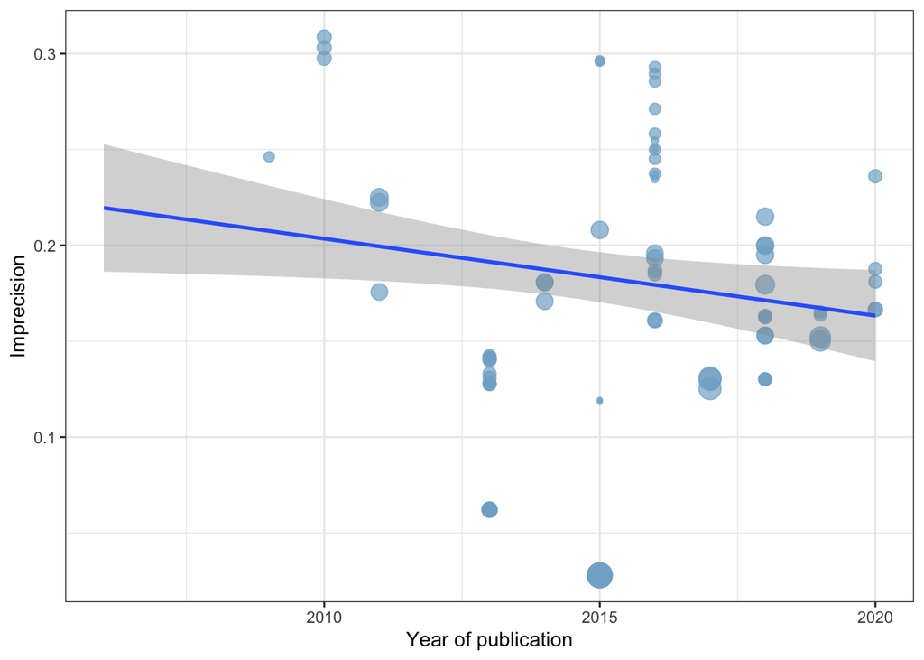

### Citations

Linear mixed-effects model. Taking into effect clustering of ESs due to originating from the same study. Using square root of variance to make the distribution normal.

```
##                     Estimate Std. Error       df    t value     Pr(>|t|)
## (Intercept)       0.25744739  0.1480949 35.06097  1.7383952 0.0909174062
## scale(pubYear)   -0.27547032  0.2243247 35.04534 -1.2279980 0.2276317146
## scale(journalH5) -0.57086418  0.1477786 35.00361 -3.8629704 0.0004631327
## scale(citations) -0.01795607  0.1753006 35.03060 -0.1024302 0.9189993494
```

#### Scatterplot precision <-> citations

The relationship between precision (sqrt of variance) and number of citations (log).

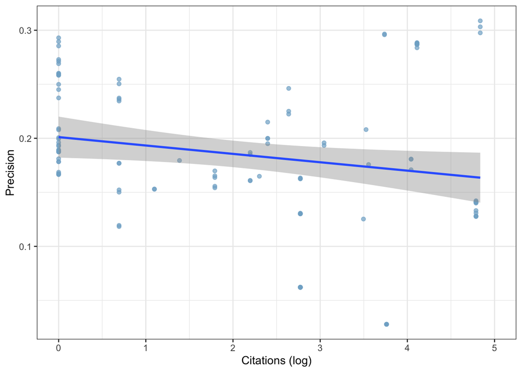

### H5 index

Linear mixed-effects model. Taking into effect clustering of ESs due to originating from the same study. Using square root of variance to make the distribution normal.

```
##                    Estimate Std. Error       df   t value     Pr(>|t|)
## (Intercept)       0.1824780  0.1345587 37.03098  1.356122 0.1832722142
## scale(journalH5) -0.5913425  0.1463093 36.99773 -4.041727 0.0002578466
```

#### Scatterplot precision <-> journal H5

The relationship between precision (sqrt of variance) and H5 index of the journal.

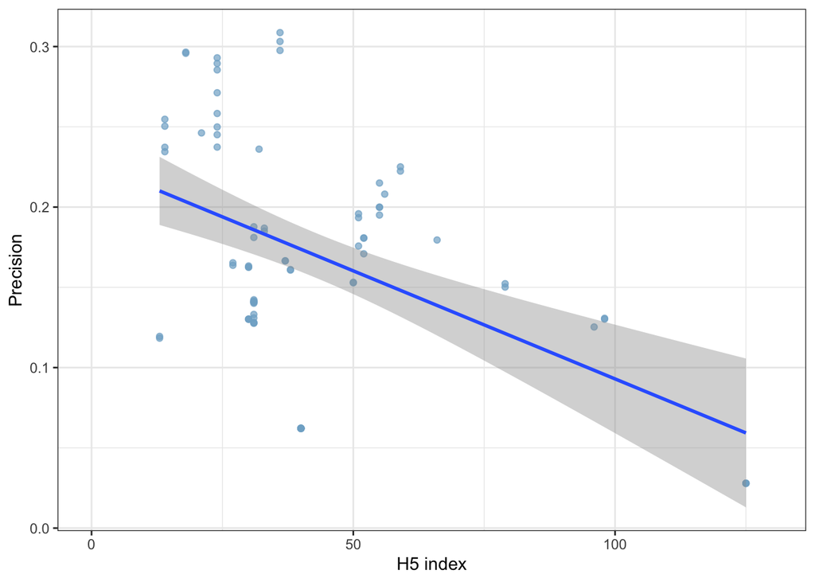

### Decline effect

Linear mixed-effects model. Taking into effect clustering of ESs due to originating from the same study.

```
##                    Estimate Std. Error       df    t value    Pr(>|t|)
## (Intercept)     -0.12604052  0.1294743 48.96848 -0.9734790 0.335099745
## scale(sqrt(vi))  0.47504387  0.1366525 50.45279  3.4762901 0.001054898
## scale(pubYear)   0.09607267  0.1360602 51.60436  0.7061043 0.483299072
```

### Citation bias

Do more highly-cited studies report larger effect sizes?

```
##                      Estimate Std. Error       df    t value      Pr(>|t|)
## (Intercept)       0.165208704 0.03672787 34.58683  4.4981839 0.00007380978
## scale(pubYear)   -0.023853592 0.05545167 34.12625 -0.4301690 0.66977709791
## scale(journalH5) -0.061728929 0.03619992 32.83111 -1.7052229 0.09759909554
## scale(citations)  0.006521344 0.04317863 33.55596  0.1510318 0.88085495904
```

```
##                      Estimate Std. Error       df     t value     Pr(>|t|)
## (Intercept)       0.146168901 0.03726855 32.94095  3.92204408 0.0004204795
## scale(pubYear)    0.002750211 0.05598499 33.31917  0.04912409 0.9611137038
## scale(journalH5) -0.024349490 0.04039371 31.89749 -0.60280396 0.5509012300
## scale(citations)  0.007356391 0.04223893 32.51821  0.17416138 0.8628183892
## scale(vi)         0.070183802 0.03650919 35.56280  1.92235971 0.0625996805
```

## Sensitivity analyses

### Risk of bias assessment

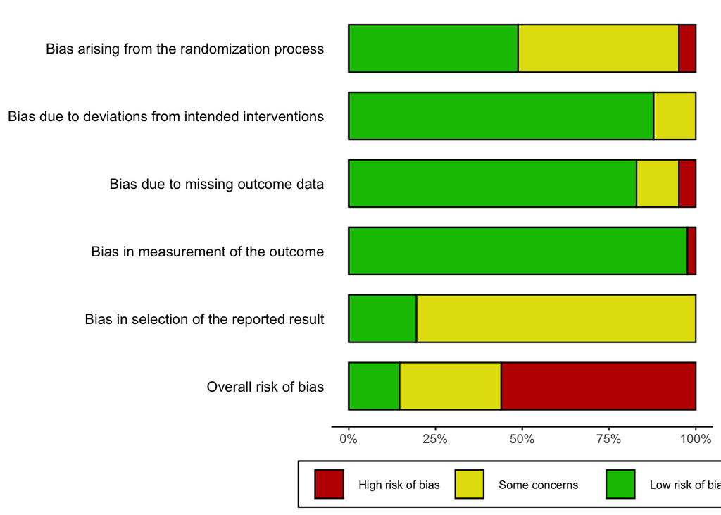

Moderator analysis for risk of bias

```
## $k
##
##           Low Some concerns          High
##            14            30            75
##
## $test
##                              Coef. Estimate     SE t-stat p-val (z) Sig.
## 1           factor(overallBias)Low   0.0985 0.0394   2.50    0.0125    *
## 2 factor(overallBias)Some concerns   0.4100 0.1113   3.68    <0.001  ***
## 3          factor(overallBias)High   0.1729 0.0739   2.34    0.0193    *
##
## $CIs
##                               Coef Estimate     SE d.f. Lower 95% CI
## 1           factor(overallBias)Low   0.0985 0.0394  Inf       0.0212
## 2 factor(overallBias)Some concerns   0.4100 0.1113  Inf       0.1919
## 3          factor(overallBias)High   0.1729 0.0739  Inf       0.0280
##   Upper 95% CI
## 1        0.176
## 2        0.628
## 3        0.318
##
## $`RVE Wald test`
##  test Fstat df_num df_denom  p_val sig
##   HTZ  3.41      2     18.2 0.0553   .
```

### Excluding effects based on inconsistent means or SDs

#### GRIM test, testing the inconsistencies in means

```
##
##    0    1    2 <NA>
##   70    5   10   34
```

#### GRIMMER test, testing the inconsistencies in SD (and means)

```
##
##    0    1    2 <NA>
##   41    8   11   59
```

```
## $`Count of GRIM/GRIMMER inconsistencies`
##
## FALSE  TRUE
##    41    19
##
## $test
##                                                  Coef. Estimate     SE t-stat
## 1 factor(as.logical(inconsistenciesCountGRIMMER))FALSE    0.344 0.0856   4.02
## 2  factor(as.logical(inconsistenciesCountGRIMMER))TRUE    0.299 0.1510   1.98
##   p-val (z) Sig.
## 1    <0.001  ***
## 2    0.0476    *
##
## $CIs
##                                                   Coef Estimate     SE d.f.
## 1 factor(as.logical(inconsistenciesCountGRIMMER))FALSE    0.344 0.0856  Inf
## 2  factor(as.logical(inconsistenciesCountGRIMMER))TRUE    0.299 0.1510  Inf
##   Lower 95% CI Upper 95% CI
## 1       0.1763        0.512
## 2       0.0031        0.595
##
## $`RVE Wald test`
##  test Fstat df_num df_denom p_val sig
##   HTZ 0.121      1     3.17  0.75
```

### Excluding effects reported in studies with possible conflicts of interests

```
## $`Count of effects reported in studies with CoI`
##
##  0  1
## 66 41
##
## $test
##                                       Coef. Estimate    SE t-stat p-val (z)
## 1 factor(as.logical(data$possibleCOI))FALSE    0.240 0.071   3.38    <0.001
## 2  factor(as.logical(data$possibleCOI))TRUE    0.363 0.103   3.54    <0.001
##   Sig.
## 1  ***
## 2  ***
##
## $CIs
##                                        Coef Estimate    SE d.f. Lower 95% CI
## 1 factor(as.logical(data$possibleCOI))FALSE    0.240 0.071  Inf        0.101
## 2  factor(as.logical(data$possibleCOI))TRUE    0.363 0.103  Inf        0.162
##   Upper 95% CI
## 1        0.379
## 2        0.564
##
## $`RVE Wald test`
##  test Fstat df_num df_denom p_val sig
##   HTZ 0.977      1     49.3 0.328
```

### Numerical inconsistencies in reported p-values

```
## [1] 469
```

```
## [1] 19
```

```
##
##     FALSE      TRUE
## 0.8952991 0.1047009
```

```
##       TRUE
## 0.08163265
```

```
## [1] 0.5789474
```